# The Raster Tutorial

## Load a raster from a file (from the package)

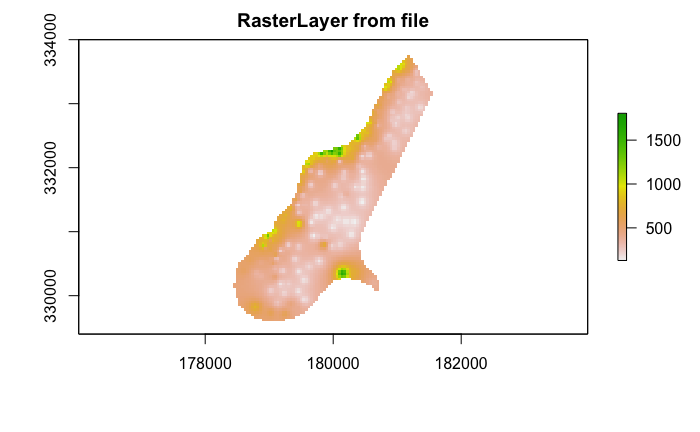

```r
filename <- system.file("external/test.grd", package="raster")
r <- raster(filename)
plot(r, main='RasterLayer from file')
```

```r
r1 <- r2 <- r3 <- raster(nrow=10, ncol=10)
# Assign random cell values
values(r1) <- runif(ncell(r1))
values(r2) <- runif(ncell(r2))
values(r3) <- runif(ncell(r3))
# combine three RasterLayer objects into a RasterStack
s <- stack(r1, r2, r3)
s
```

```
class      : RasterStack
dimensions : 10, 10, 100, 3  (nrow, ncol, ncell, nlayers)
resolution : 36, 18  (x, y)
extent     : -180, 180, -90, 90  (xmin, xmax, ymin, ymax)
crs        : +proj=longlat +datum=WGS84 +ellps=WGS84 +towgs84=0,0,0
names      :     layer.1,     layer.2,     layer.3
min values : 0.014334920, 0.008476881, 0.002392532
max values :   0.9807531,   0.9933630,   0.9803610
```

# Raster Algebra

Ordinary algebraic operators and lobical operators, as well as some functions, can operate on raster values

Using replacement functions

```r
s[s < 15] <- 15
getValues(s)
```

[output not shown]

Combining stack objects:

```r
r <- raster(ncol = 5, nrow = 5)
r[] <- 1 # another way to set values
s <- stack(r, r + 1)
x <- s + s
head(x[])
```

```
     layer.1 layer.2
[1,]       2       4
[2,]       2       4
[3,]       2       4
[4,]       2       4
[5,]       2       4
[6,]       2       4
```

```r
s <- stack(r, r + 1, r + 1)
q <- stack(r + 3, r + 2, r + 4)
head(q[])
```

```
     layer.1 layer.2 layer.3
[1,]       4       3       5
[2,]       4       3       5
[3,]       4       3       5
[4,]       4       3       5
[5,]       4       3       5
[6,]       4       3       5
```

```r
y <- s + q
head(y[])
```

```
     layer.1 layer.2 layer.3
[1,]       5       5       7
[2,]       5       5       7
[3,]       5       5       7
[4,]       5       5       7
[5,]       5       5       7
[6,]       5       5       7
```

Summary functions acting on RasterLayers also return RasterLayers

```r
r <- raster(ncol = 5, nrow = 5)
r[] <- runif(ncell(r))
q <- stack(r, r + 2)
mean(q)
```

```
class      : RasterLayer
dimensions : 5, 5, 25  (nrow, ncol, ncell)
resolution : 72, 36  (x, y)
extent     : -180, 180, -90, 90  (xmin, xmax, ymin, ymax)
crs        : +proj=longlat +datum=WGS84 +ellps=WGS84 +towgs84=0,0,0
source     : memory
names      : layer
values     : 1.094157, 1.986244  (min, max)
```

Note that we can also pull out the values as before, and that the mean has been computed across layers

```r
head(q[])
```

```
        layer.1  layer.2
[1,] 0.32060434 2.320604
[2,] 0.43230997 2.432310
[3,] 0.25813237 2.258132
[4,] 0.98624357 2.986244
[5,] 0.70992292 2.709923
[6,] 0.09415701 2.094157
```

```r
head(mean(q)[])
```

```
[1] 1.320604 1.432310 1.258132 1.986244 1.709923 1.094157
```

Use the `cellStats` function to summarize the stats of the layers themselves

```r
cellStats(q, 'sum')
```

```
 layer.1  layer.2
12.17295 62.17295
```

```r
cellStats(q, 'max')
```

```
[1] 0.9862436 2.9862436
```

# High-level methods

These are functions we can expect to find in dedicated GIS software, for transforming our rasters.

## Modifying a Raster

Changing spatial extents: * `crop` - take subset of a larger raster object, where the subset’s extent is defined by the extent of another raster object * `trim` - crops a raster by removing the outer rows and columns that only contain `NA`s. Similarly, `extend` does the opposite and fills out the extent of a `trim`med raster with `NA` space * `merge` - merge two or more raster objects into a single new object. * `aggregate`/`disaggregate` - in the case of `aggregate` need to provide a function specifying what to do with the grouped/ungrouped cell values * `resample` - we may need nearly the same cell size, while shifting cell centers - this function performs nearest neighbors assignments (categorical data) or bilinear interpolation (numerical data) * `focal` - a transformation method that works only for single RasterLayer objects, where I can replace a neighborhood of points with a particular value (this is cool, like a kernel filter)

```
class       : RasterLayer
dimensions  : 100, 100, 10000  (nrow, ncol, ncell)
resolution  : 3.6, 1.8  (x, y)
extent      : -180, 180, -90, 90  (xmin, xmax, ymin, ymax)
coord. ref. : +proj=longlat +datum=WGS84 +ellps=WGS84 +towgs84=0,0,0
data source : in memory
names       : layer
values      : 1, 1  (min, max)
```

```
class       : RasterLayer
dimensions  : 10, 10, 100  (nrow, ncol, ncell)
resolution  : 36, 18  (x, y)
extent      : -180, 180, -90, 90  (xmin, xmax, ymin, ymax)
coord. ref. : +proj=longlat +datum=WGS84 +ellps=WGS84 +towgs84=0,0,0
data source : in memory
names       : layer
values      : 100, 100  (min, max)
```

What happens when we try to aggregate up by a factor?

```
class       : RasterLayer
dimensions  : 100, 100, 10000  (nrow, ncol, ncell)
resolution  : 3.6, 1.8  (x, y)
extent      : -180, 180, -90, 90  (xmin, xmax, ymin, ymax)
coord. ref. : +proj=longlat +datum=WGS84 +ellps=WGS84 +towgs84=0,0,0
data source : in memory
names       : layer
values      : 1, 1  (min, max)
```

```
class       : RasterLayer
dimensions  : 4, 4, 16  (nrow, ncol, ncell)
resolution  : 108, 54  (x, y)
extent      : -180, 252, -126, 90  (xmin, xmax, ymin, ymax)
coord. ref. : +proj=longlat +datum=WGS84 +ellps=WGS84 +towgs84=0,0,0
data source : in memory
names       : layer
values      : 100, 900  (min, max)
```

A bunch of examples:

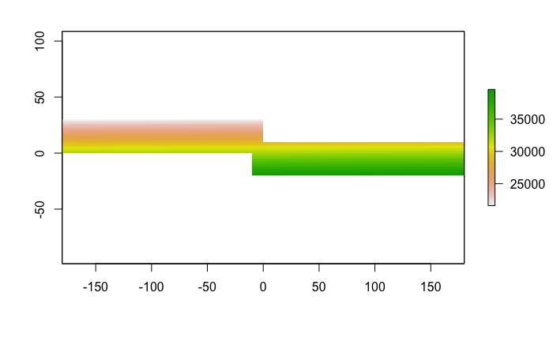

## Resampling

Transfers values between non-matching raster objects, ie if the resolutions of the two objects don’t match.  
Bilinear interpolation is the default method for resolving breaking up pixels, although “ngb” is also an option for using the nearest neighbor

```
class       : RasterLayer
dimensions  : 3, 3, 9  (nrow, ncol, ncell)
resolution  : 120, 60  (x, y)
extent      : -180, 180, -90, 90  (xmin, xmax, ymin, ymax)
coord. ref. : +proj=longlat +datum=WGS84 +ellps=WGS84 +towgs84=0,0,0
data source : in memory
names       : layer
values      : 1, 9  (min, max)
```

```
class       : RasterLayer
dimensions  : 10, 10, 100  (nrow, ncol, ncell)
resolution  : 36, 18  (x, y)
extent      : -180, 180, -90, 90  (xmin, xmax, ymin, ymax)
coord. ref. : +proj=longlat +datum=WGS84 +ellps=WGS84 +towgs84=0,0,0
```

```
class       : RasterLayer
dimensions  : 10, 10, 100  (nrow, ncol, ncell)
resolution  : 36, 18  (x, y)
extent      : -180, 180, -90, 90  (xmin, xmax, ymin, ymax)
coord. ref. : +proj=longlat +datum=WGS84 +ellps=WGS84 +towgs84=0,0,0
data source : in memory
names       : layer
values      : -0.4, 10.4  (min, max)
```

We can resample up or down; note that resampling doesn’t actually conserve numerical counts, so we can’t use this trick on, say, the population surfaces.

```
class       : RasterLayer
dimensions  : 3, 3, 9  (nrow, ncol, ncell)
resolution  : 120, 60  (x, y)
extent      : -180, 180, -90, 90  (xmin, xmax, ymin, ymax)
coord. ref. : +proj=longlat +datum=WGS84 +ellps=WGS84 +towgs84=0,0,0
data source : in memory
names       : layer
values      : 13.83333, 87.16667  (min, max)
```

## Distance calculations

- `distance` - computes shortest distance between cells (x, y)
- `pointDistance` - computes shortest distance from one point to a group of points
- `gridDistance` - computes distance following grid cells that can be traversed

Refer also to the `gdistance` package for more of these

## Spatial configuration

- `adjacency` - which cells are adjacent which other cells (yes!)
- `clump`
- `boundaries`

# Cell-level functions

```
       x  y
[1,] 175 75
```

Accessing cell values:

```
[1] 456.878 485.538 550.788 580.339 590.029
```

Can also “extract” values given a list of cells:

```
[1] 456.878 485.538 550.788 580.339 590.029
```